# Using ASMODEE to detect trend changes in COVID-19

# 2 Trends in cases

## 2.1 Data

```r
cases_i <- dat %>%
  incidence(date,
            counts = c(cases, tests, deaths),
            groups = c(report_country)) %>%
  mutate(weekend = day_of_week(date_index)) %>% # add weekday
  keep_last(7 * 7) %>%
  mutate(weekday = factor(weekdays(date_index)))

cases_i
## An incidence object: 2,450 x 7
## date range: [2021-07-09] to [2021-08-26]
## cases: 1260956
## tests: 5687892
## deaths: 31806
## interval: 1 day
##
##    date_index report_country           cases tests deaths weekend      weekday
##    <date>     <chr>                    <dbl> <dbl>  <dbl> <fct>        <fct>
##  1 2021-07-09 Algeria                    620     0     12 rest_of_week Friday
##  2 2021-07-09 Angola                     102     0      0 rest_of_week Friday
##  3 2021-07-09 Benin                        0     0      0 rest_of_week Friday
##  4 2021-07-09 Botswana                  1411     0     14 rest_of_week Friday
##  5 2021-07-09 Burkina Faso                 1     0      0 rest_of_week Friday
##  6 2021-07-09 Burundi                     23     0      0 rest_of_week Friday
##  7 2021-07-09 Cabo Verde                  56     0      0 rest_of_week Friday
##  8 2021-07-09 Cameroon                     0     0      0 rest_of_week Friday
##  9 2021-07-09 Central African Republic     0     0      0 rest_of_week Friday
## 10 2021-07-09 Chad                         0     0      0 rest_of_week Friday
## # ... with 2,440 more rows
```

We also remove countries which reported less than 100 cases or tests in the last 7 weeks:

```r
analysed_countries <- to_keep <- cases_i %>%
  group_by(report_country) %>%
  summarise(total_cases = sum(cases, na.rm = TRUE),
            total_tests = sum(tests, na.rm = TRUE)) %>%
  filter(total_cases > 100 | total_tests > 100) %>%
  pull(report_country)

notes <- NULL
removed_countries <- setdiff(cases_i$report_country, to_keep)
if (length(removed_countries)) {
  msg <- paste0("The following countries reported < 100 cases/tests over the last 7 weeks ",
                "and were not included in further analyses:\n",
                paste(removed_countries, collapse = ", "))
  message(msg)
  notes <- c(notes, gsub("\n", "<br>", msg))
}
## The following countries reported < 100 cases/tests over the last 7 weeks and were not included in further analyses:
## Chad, Comoros, Saint Helena

n_countries <- length(unique(to_keep))

cases_i <- cases_i %>%
  filter(report_country %in% to_keep)
```

**Important note:**  
The following countries reported < 100 cases/tests over the last 7 weeks and were not included in further analyses:  
Chad, Comoros, Saint Helena

## 2.2 Model generators

Here we use some ad-hoc code to handle cases where the training set contains not one, but 2 temporal trends. The proposed solution is to duplicate each candidate model of the form `model(response ~ xxx + time)` into:

1. the same model
2. a set of *k* models in the form: `model(response ~ xxx + change_k:time + time)` where `change_k` is a binary qualitative variable marking before/after day *k*; the set of models generated will explore various values of *k*

### 2.2.1 Adding binary variables to the data

```r
cases_i <- cases_i %>%
  mutate(day = as.integer(date_index - min(date_index)))

min_k <- 9
max_k <- 25
k_values <- min_k:max_k
change_k_df <- lapply(k_values,
                       function(k)
                         cases_i %>%
                         group_by(report_country) %>%
                         transmute(if_else(day <= k, "before", "after")) %>%
                         pull(2)) %>%
  data.frame() %>%
  tibble() %>%
  setNames(paste0("change_", k_values))

cases_i <- cases_i %>%
  bind_cols(change_k_df)
```

### 2.2.2 Define split models

```r
model_grid <- expand.grid(
    c("", "tests"), # with/without tests
    "date_index", # time effect
    c("", "weekend", "weekday"), # optional offsets
    c("", paste("date_index*change", k_values, sep = "_")) # optional split
)

## convert to text
predictors_txt <- model_grid %>%
  apply(1, paste, collapse = " + ")

## cleanup
predictors_txt <- gsub("(\\+[ ]*)+[ ]*\\+", " + ", predictors_txt) # +... + -> +
predictors_txt <- sub("^[ ]*\\+", "", predictors_txt) # heading +
predictors_txt <- sub("\\+[ ]*$", "", predictors_txt) # trailing +
predictors_txt <- sub("^[ ]+", "", predictors_txt) # heading spaces
predictors_txt <- sub("[ ]+$", "", predictors_txt) # trailing spaces
predictors_txt <- sub("[ ]+", " ", predictors_txt) # multiple spaces

## add constant models
predictors_txt <- c("1", predictors_txt)
```

## 2.3 Candidate models

Candidate models are generated to include:

```r
models_txt  <- c(
    ## sprintf("lm_model(cases ~ %s)", predictors_txt), # linear models
    sprintf("glm_model(cases ~ %s, family = gaussian)", predictors_txt) , # Gaussian GLMs
    sprintf("glm_nb_model(cases ~ %s)", predictors_txt) # NegBin GLMs
)

length(models_txt)
```

```
## [1] 218
```

```r
head(models_txt)
```

```
## [1] "glm_model(cases ~ 1, family = gaussian)"                            "glm_model(cases ~ date_index, family = gaussian)"
## [3] "glm_model(cases ~ tests + date_index, family = gaussian)"           "glm_model(cases ~ date_index + weekend, family = gaussian)"
## [5] "glm_model(cases ~ tests + date_index + weekend, family = gaussian)" "glm_model(cases ~ date_index + weekday, family = gaussian)"
```

```r
tail(models_txt)
```

```
## [1] "glm_nb_model(cases ~ date_index +  date_index*change_25)"                  "glm_nb_model(cases ~ tests + date_index  +  date_index*change_25)"
## [3] "glm_nb_model(cases ~ date_index + weekend + date_index*change_25)"         "glm_nb_model(cases ~ tests + date_index + weekend + date_index*change_25)"
## [5] "glm_nb_model(cases ~ date_index + weekday + date_index*change_25)"         "glm_nb_model(cases ~ tests + date_index + weekday + date_index*change_25)"
```

```r
cases_models <- lapply(models_txt, function(e) eval(parse(text = e)))
```

## 2.4 Run ASMODEE

Case data can be problematic because of occasional artifactual ‘zeros’, which reflect the absence of reporting on a given day, typically followed by a higher case count reflecting the backlog. Unfortunately, this often throws off the Negbin GLM, which is most of the time our best option: Poisson GLM drastically under-estimates variance and sees most points as outliers, and Gaussian GLM can predict negative numbers.

```r
# run asmodee
cases_res <- cases_i %>%
  asmodee(cases_models, k = 7,
          simulate_pi = FALSE)

# keep only successful runs
to_keep <- vapply(cases_res$output, inherits, logical(1), "trendbreaker")
cases_res <- cases_res %>%
  filter(to_keep)

## ## for loop for debugging purposes
## split_x <- cases_i %>%
##   flag_low_counts(set_missing = TRUE, threshold = 0.001) %>%
##   split(cases_i$report_country)
## cases_res <- list()
## for (i in seq_along(split_x)) {
##   cases_res[[i]] <- asmodee(split_x[[i]], cases_models, fixed_k = 7, method = evaluate_aic,
##           include_warnings = FALSE,
##           simulate_pi = FALSE)
## }
```

```r
# handle countries with no results
countries_missing_asmodee <- setdiff(analysed_countries, cases_res$report_country)
if (length(countries_missing_asmodee)) {
  msg <- paste0("ASMODEE results could not be produced for the following countries:\n",
                paste(countries_missing_asmodee, collapse = ", "))
  message(msg)
  notes <- c(notes, gsub("\n", "<br>", msg))
}
```

## 2.5 Plot with all countries

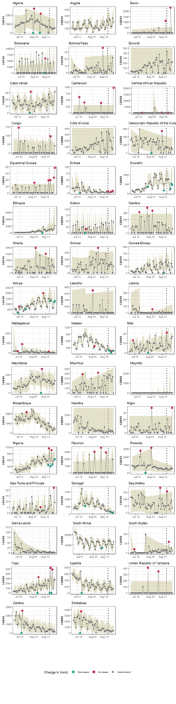

```r
cases_res %>%
  plot(ncol = 3)
```

## 2.6 Countries summaries

We use `summary` to have an overview of outliers by country:

```r
cases_outliers <- cases_res %>%
  summary() %>%
  select(Country = report_country,
         n_recent_increases,
         n_recent_decreases,
         p_recent_outliers)

DT::datatable(cases_outliers,
              options = list(
                  pageLength = nrow(cases_outliers)))
```

|  | Country | n_recent_increases | n_recent_decreases | p_recent_outliers |
| --- | --- | --- | --- | --- |
| 1 | Algeria | 0 | 0 | 0.30166270390625 |
| 2 | Angola | 0 | 0 | 0.30166270390625 |
| 3 | Benin | 1 | 0 | 0.0443805421875 |
| 4 | Botswana | 0 | 0 | 0.30166270390625 |
| 5 | Burkina Faso | 0 | 0 | 0.30166270390625 |
| 6 | Burundi | 0 | 0 | 0.30166270390625 |
| 7 | Cabo Verde | 0 | 0 | 0.30166270390625 |
| 8 | Cameroon | 1 | 0 | 0.0443805421875 |
| 9 | Central African Republic | 1 | 0 | 0.0443805421875 |
| 10 | Congo | 1 | 0 | 0.0443805421875 |

[output cut: 37 more lines]

# 3 Growth rates

## 3.1 Growth rates

These estimates of daily growth rates are based on negative binomial GLM fitted to the last 3 weeks of data. Positive values indicate epidemic growth, and negative values indicate decline. Confidence intervals including zero indicate uncertain trends.

```r
#  estimate the growth rates days before (going back: d2 - d10)
## we use future_lapply to speed up computations
df_r  <- future.apply::future_lapply(
  0:params$tadpole_size,
  function(d)
  cases_i %>%
    select(-deaths, -tests) %>%
    keep_last(3*7 + d) %>%
    keep_first(3*7) %>%
    fit_curve() %>%
    growth_rate() %>%
    mutate(last_day = d) %>%
    select(report_country, r, r_lower, r_upper, last_day),
  future.seed = TRUE) %>%
  bind_rows() %>%
  mutate(type = case_when(r_lower > 0 ~ "growth",
                          r_upper < 0 ~ "decline",
                          TRUE ~ "uncertain"),
         type = factor(type, levels = c("growth", "uncertain", "decline")))
```

```r
countries_missing_r <- setdiff(analysed_countries, df_r$report_country)

# handle countries with no results
if (length(countries_missing_r)) {
  msg <- paste0("Estimates of *r* could not be produced for the following countries:\n",
                paste(countries_missing_r, collapse = ", "))
  message(msg)
  notes <- c(notes, gsub("\n", "<br>", msg))
}
```

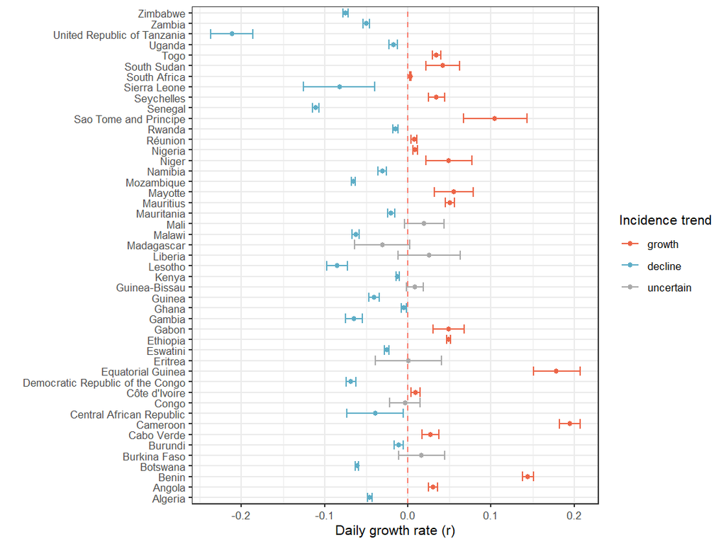

```r
scale_type <- scale_color_manual(
  "Incidence trend",
  values = c(growth = "#EC6446",
             decline = "#5DADC6",
             uncertain = "#A9A9A9")
)

df_r %>%
  filter(last_day == 0) %>%
  ggplot(aes(y = report_country, x = r, color = type)) +
  geom_errorbar(aes(xmin = r_lower, xmax = r_upper)) +
  geom_point() +
  theme_bw() +
  scale_type +
#  scale_x_continuous(labels=scales::percent) +
  geom_vline(xintercept = 0, linetype = 2, color = "salmon") +
  labs(x = "Daily growth rate (r)", y = "")
```

# 4 Overall dynamics

## 4.1 Merging indicators

```r
# Population by country
df_pop <- dat %>%
  group_by(report_country, iso3) %>%
  summarise(population = mean(population, na.rm = TRUE))
## `summarise()` has grouped output by 'report_country'. You can override using the `.groups` argument.

# Cumulative incidence over the last week (going back: w1) per 100k inhabitants
df_recent_incid <- future.apply::future_lapply(
   0:params$tadpole_size,
  function(d)
    cases_i %>%
      keep_last(7 + d) %>%
      keep_first(7) %>%
      group_by(report_country) %>%
      summarise(n_cases = sum(cases),
                n_deaths = sum(deaths)) %>%
      left_join(df_pop) %>%
      mutate(case_incid_last_week = 1e6 * n_cases / population,
             death_incid_last_week = 1e6 * n_deaths / population,
             last_day = d),
  future.seed = TRUE) %>%
  bind_rows()
## Joining, by = "report_country"
## Joining, by = "report_country"
## Joining, by = "report_country"
## Joining, by = "report_country"
## Joining, by = "report_country"
## Joining, by = "report_country"
## Joining, by = "report_country"
## Joining, by = "report_country"

# Table containing r, incidence per capita, recent increases
df_dynamics <- df_recent_incid %>%
  left_join(df_r) %>%
  left_join(cases_outliers, by = c("report_country" = "Country"))
## Joining, by = c("report_country", "last_day")

# Add data on past peak incidence
minimum_peak <- 0

df_peaks <- dat %>%
  filter(who_region == params$who_region,
         date < (data_stamp - 7)) %>%
  group_by(report_country) %>%
  summarise(incid_peak = max(case_new_7d_100k, na.rm = TRUE)) %>%
  mutate(incid_peak = incid_peak * 10) %>% # incidence per 100k -> 1M
  filter(incid_peak >= minimum_peak)

df_dynamics <- df_dynamics %>%
  left_join(df_peaks, by = "report_country") %>%
  mutate(perc_peak = case_incid_last_week / incid_peak)

# Add info on significance of r (> 0 or < 0)
df_dynamics <- df_dynamics %>%
  mutate(r_signif = if_else(r_lower > 0 | r_upper < 0, "yes", "no"))

# Add 'net_increase' over last week
df_dynamics <- df_dynamics %>%
  mutate(net_increases = n_recent_increases - n_recent_decreases,
         net_increases = if_else(net_increases > 0L, net_increases, 0L))

# data with only current time frame
df_dynamics_current <- df_dynamics %>%
  filter(last_day == 0)
```

```r
countries_missing_peak <- setdiff(analysed_countries, df_peaks$report_country)

# handle countries with no results
if (length(countries_missing_peak)) {
  msg <- sprintf(
    "Past incidence peaks could not be found (no case previously reported) for the following countries:\n%s",
    minimum_peak,
    paste(countries_missing_peak, collapse = ", "))
  message(msg)
  notes <- c(notes, gsub("\n", "<br>", msg))
}
```

## 4.2 Deaths, growth rates and changes

### 4.2.1 Scales

```r
scale_signif <- scale_shape_manual(
  "Significant growth/decline",
  values = c(yes = 19, no = 1)
)

scale_asmodee <- scale_colour_steps(
  "Days in last week\nabove\nexpectations",
  low = "#5b7bb5",
  high = "#d10031",
  breaks = 0:7,
  limits = c(0,7))
```

### 4.2.2 Main figure

This figure reports:

- growth rate based on the last 3 weeks of data
- last weeks’s deaths per capita
- significant increases detected by ASMODEE in the last week

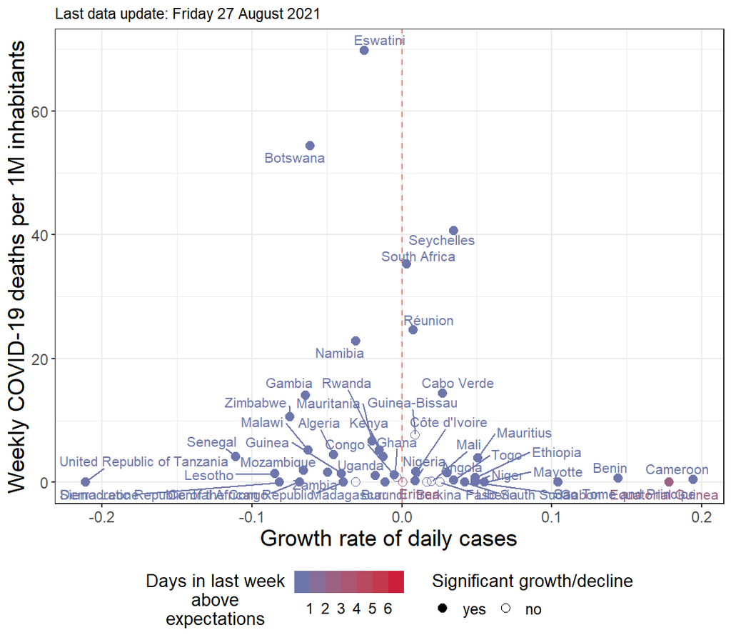

```r
# tadpole plot
plot_overall_deaths <- df_dynamics_current %>%
  ggplot(aes(x = r, y = death_incid_last_week, color = net_increases)) +
  theme_bw() +
  geom_vline(xintercept = 0, linetype = 2, color = "salmon") +
  geom_point(aes(shape = r_signif), size = 3) +
  geom_text_repel(
    data = df_dynamics_current,
    aes(label = report_country), max.overlaps = 100,
                  max.time = 2, max.iter = 1e5) +
  scale_signif +
  scale_asmodee +
  labs(x = "Growth rate of daily cases",
       y = "Weekly COVID-19 deaths per 1M inhabitants",
       subtitle = sprintf("Last data update: %s",
                          format(data_stamp, "%A %d %B %Y"))) +
  theme(legend.position = "bottom",
        axis.text = element_text(size = 12),
        axis.title = element_text(size = 18),
        plot.subtitle = element_text(size = 12),
        legend.text = element_text(size = 12),
        legend.title = element_text(size = 14),
        legend.title.align = 0.5) +
  guides(
    color = guide_colorsteps(order = 1),
    shape = guide_legend(title.position = "top", order = 2))

plot_overall_deaths
```

### 4.2.3 Tadpole version

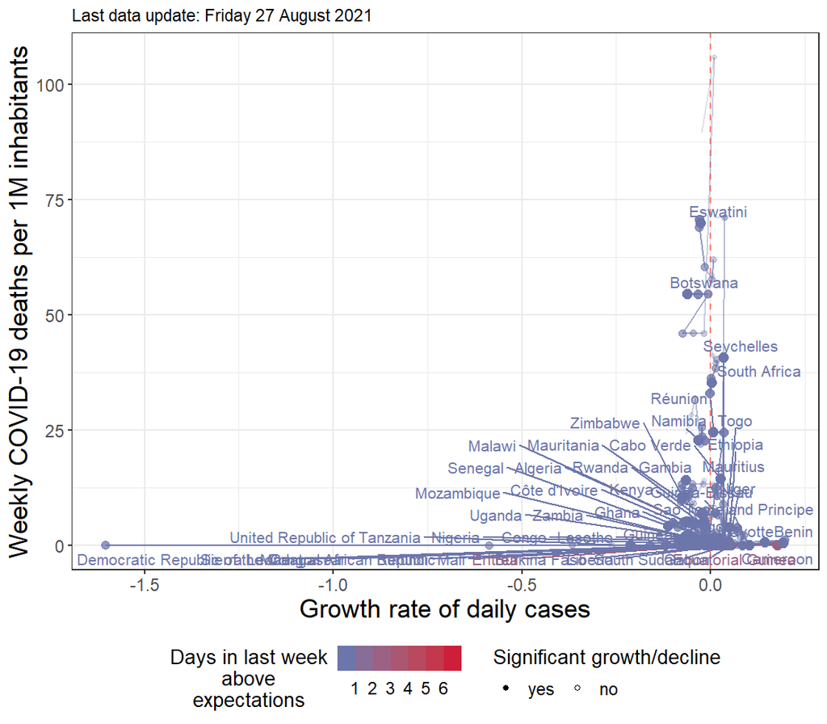

```r
# tadpole plot
plot_tadpole_deaths <- df_dynamics %>%
  group_by(report_country) %>%
  arrange(last_day) %>%
  ggplot(aes(x = r, y = death_incid_last_week, color = net_increases)) +
  theme_bw() +
  geom_vline(xintercept = 0, linetype = 2, color = "salmon") +
  geom_path(aes(group = report_country, alpha = last_day)) +
  geom_point(aes(size = last_day, alpha = last_day, shape = r_signif)) +
  geom_text_repel(
    data = df_dynamics_current,
    aes(label = report_country), max.overlaps = 100,
                  max.time = 2, max.iter = 1e5) +
  scale_signif +
  scale_asmodee +
  scale_alpha_continuous(trans = "reverse") +
  scale_size_continuous(range = c(0.5, 3), trans = "reverse") +
  labs(x = "Growth rate of daily cases",
       y = "Weekly COVID-19 deaths per 1M inhabitants",
       subtitle = sprintf("Last data update: %s",
                          format(data_stamp, "%A %d %B %Y"))) +
  theme(legend.position = "bottom",
        axis.text = element_text(size = 12),
        axis.title = element_text(size = 18),
        plot.subtitle = element_text(size = 12),
        legend.text = element_text(size = 12),
        legend.title = element_text(size = 14),
        legend.title.align = 0.5) +
  guides(
    color = guide_colorsteps(order = 1),
    shape = guide_legend(title.position = "top", order = 2),
    size = "none",
    alpha = "none")

plot_tadpole_deaths
```

## 4.3 Relative cases, growth and changes

### 4.3.1 Main figure

This figure reports:

- growth rate based on the last 3 weeks of data
- last weeks’s case incidence per capita, expressed as a proportion of the past peak incidence
- significant increases detected by ASMODEE in the last week

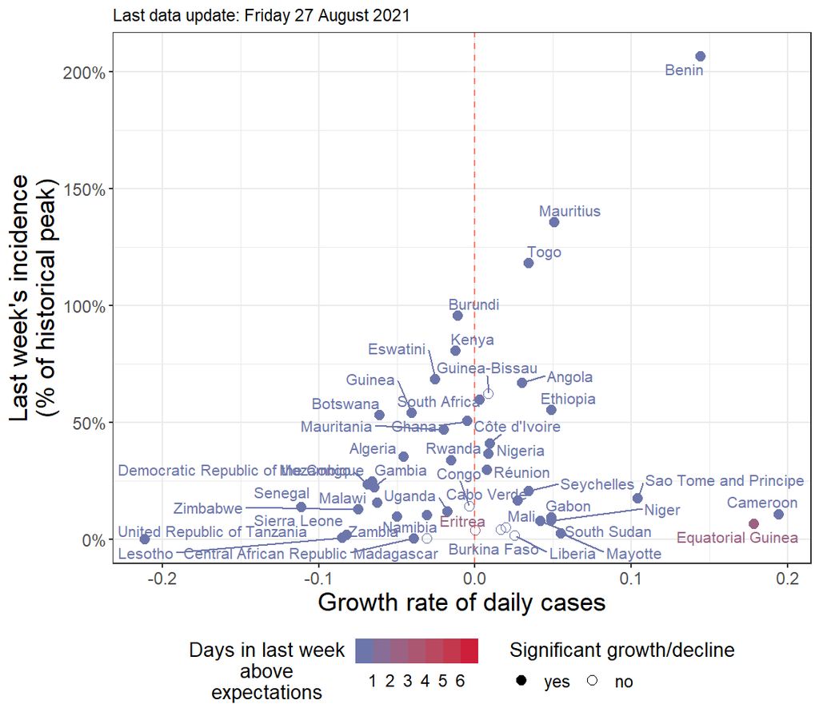

```r
plot_overall_peaks <- df_dynamics_current %>%
  ggplot(aes(x = r, y = perc_peak, color = net_increases)) +
  theme_bw() +
  geom_vline(xintercept = 0, linetype = 2, color = "salmon") +
  geom_point(aes(shape = r_signif), size = 3) +
  geom_text_repel(
    data = df_dynamics_current,
    aes(label = report_country), max.overlaps = 100,
                  max.time = 2, max.iter = 1e5) +
  scale_y_continuous(labels = scales::percent) +
  scale_signif +
  scale_asmodee +
  labs(x = "Growth rate of daily cases",
       y = "Last week's incidence\n(% of historical peak)",
       subtitle = sprintf("Last data update: %s",
                          format(data_stamp, "%A %d %B %Y"))) +
  theme(legend.position = "bottom",
        axis.text = element_text(size = 12),
        axis.title = element_text(size = 18),
        plot.subtitle = element_text(size = 12),
        legend.text = element_text(size = 12),
        legend.title = element_text(size = 14),
        legend.title.align = 0.5) +
  guides(
    color = guide_colorsteps(order = 1),
    shape = guide_legend(title.position = "top", order = 2))

plot_overall_peaks
```

### 4.3.2 Tadpole version

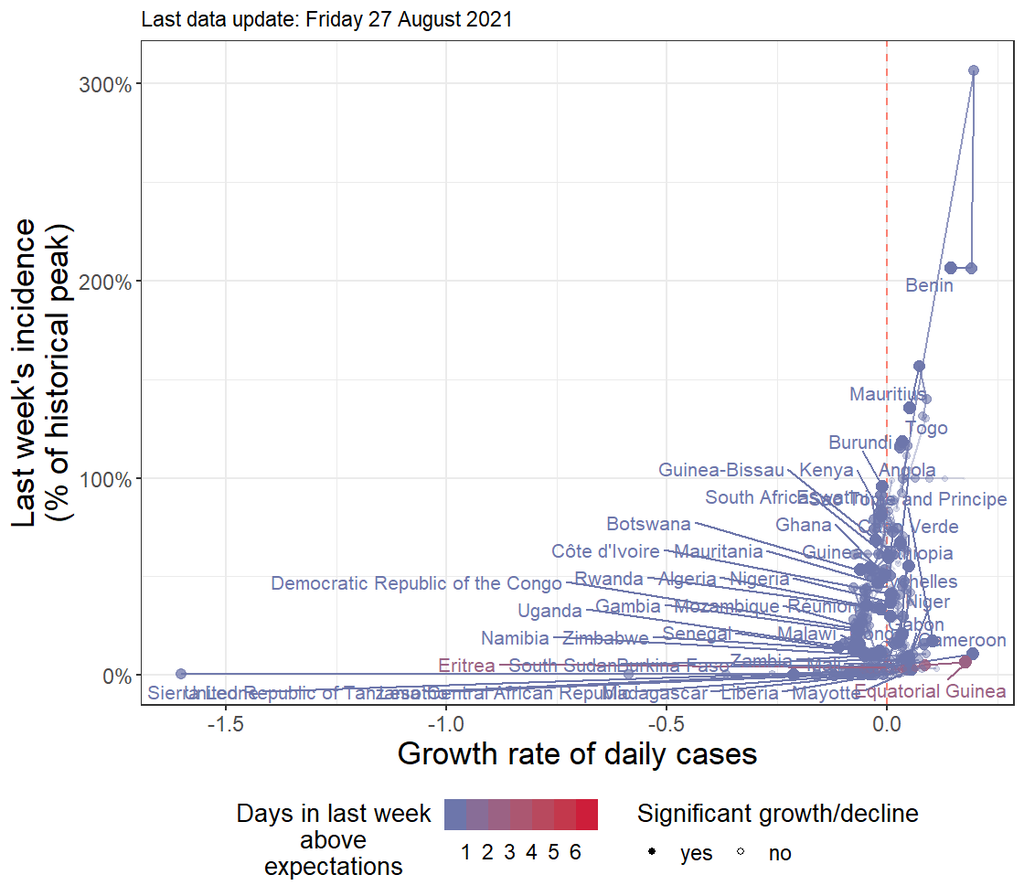

```r
plot_tadpole_peaks <- df_dynamics %>%
  group_by(report_country) %>%
  arrange(last_day) %>%
  ggplot(aes(x = r, y = perc_peak, color = net_increases)) +
  theme_bw() +
  geom_vline(xintercept = 0, linetype = 2, color = "salmon") +
  geom_path(aes(group = report_country, alpha = last_day)) +
  geom_point(aes(size = last_day, alpha = last_day, shape = r_signif)) +
  geom_text_repel(
    data = df_dynamics_current,
    aes(label = report_country), max.overlaps = 100,
                  max.time = 2, max.iter = 1e5) +
  scale_y_continuous(labels = scales::percent) +
  scale_signif +
  scale_asmodee +
  scale_alpha_continuous(trans = "reverse") +
  scale_size_continuous(range = c(0.5, 3), trans = "reverse") +
  labs(x = "Growth rate of daily cases",
       y = "Last week's incidence\n(% of historical peak)",
       subtitle = sprintf("Last data update: %s",
                          format(data_stamp, "%A %d %B %Y"))) +
  theme(legend.position = "bottom",
        axis.text = element_text(size = 12),
        axis.title = element_text(size = 18),
        plot.subtitle = element_text(size = 12),
        legend.text = element_text(size = 12),
        legend.title = element_text(size = 14),
        legend.title.align = 0.5) +
  guides(
    color = guide_colorsteps(order = 1),
    shape = guide_legend(title.position = "top", order = 2),
    size = "none",
    alpha = "none")

plot_tadpole_peaks
```

# 5 Test positivity rates (TPR)

## 5.1 Changes in TPR

The changes in TPR is determined by comparing the last estimated weekly TPR (i.e. including the last available data, excluding artifactual trailing zeros) to the TPR of the week before. TPR estimates as well as the corresponding raw numbers are generated by `assemble_data` and stored in `elr_extras`, and are identical to the values reported in the [shiny app](https://worldhealthorg.shinyapps.io/covid/). We assess the significance of changes by comparing the respective Binomial 95% confidence intervals:

```r
elr_extras <- elr_extras %>%
  mutate(
    tpr_change = case_when(
      is.na(tpr_recent) | is.na(tpr_before) ~ NA_character_,
      tpr_lower_recent >  tpr_upper_before ~ "increasing",
      tpr_upper_recent <  tpr_lower_before ~ "decreasing",
      TRUE ~ "constant"),
    tpr_change = factor(tpr_change,
                        levels = c("decreasing", "constant", "increasing")))
```

# 6 Export results

## 6.1 Create needed directories

We create output directories if they don’t already exist:

```r
target <- here::here("asmodee_outputs")
if (!dir.exists(target)) dir.create(target)

targets <- c("rds", "png", "notes")
for (e in targets) {
  target <- here::here("asmodee_outputs", e)
  if (!dir.exists(target)) dir.create(target)
}
```

## 6.2 Save ASMODEE outputs

We export the following products for further uses in other systems, in an object called `asmodee_outputs`; all objects are stored in */asmodee_outputs/rds/*:

- `summary`: summary of the ASMODEE results
- `results`: outputs of ASMODEE
- `plot_overall_deaths`: *ggplot2* object of the overall dynamics plot using death per capita on the y-axis
- `plot_overall_peaks`: *ggplot2* object of the overall dynamics plot using incidence as percentage of historical peak on the y-axis
- `df_dynamics`: a `data.frame` containing all the required info to recreate either global dynamics plots
- `elr_extras`: a `data.frame` containing additional information for countries, including TPR and vaccination coverage
- `timestamp`: the timestamp corresponding to the date of the dataset used in the analyses

```r
asmodee_outputs <- list(
  summary = cases_outliers,
  results = cases_res,
  plot_overall_deaths = plot_overall_deaths,
  plot_overall_peaks = plot_overall_peaks,
  df_dynamics = df_dynamics,
  elr_extras = elr_extras,
  timestamp = data_stamp
)

## export asmodee summary
file_name <- sprintf("asmodee_outputs_%s_%s.rds",
                     paste(params$who_region, collapse = "_"),
                     data_stamp)
path_out <- here::here("asmodee_outputs", "rds", file_name)
rio::export(asmodee_outputs, path_out)

## make a copy as latest file
latest_file_name <- sprintf("asmodee_outputs_%s_latest.rds",
                            paste(params$who_region, collapse = "_")
                            )
latest_path_out <- here::here("asmodee_outputs", "rds", latest_file_name)
file.copy(from = path_out, to = latest_path_out, overwrite = TRUE)
```

```
## [1] TRUE
```

## 6.3 Export main figures

```r
# Pinplots
## Deaths PC as y axis
fig_name <- sprintf("pinplot_deaths_%s_%s.png",
                    paste(params$who_region, collapse = "_"),
                    data_stamp)
fig_path <- here::here("asmodee_outputs", "png", fig_name)

png(fig_path, width = 22, height = 18, units = "cm", res = 150)
print(plot_overall_deaths)
dev.off()
## png
##   2

## Make a copy as 'latest'
latest_fig_name <- sprintf("pinplot_deaths_%s_latest.png",
                           paste(params$who_region, collapse = "_")
                           )
latest_fig_path <- here::here("asmodee_outputs", "png", latest_fig_name)
file.copy(from = fig_path, to = latest_fig_path, overwrite = TRUE)
```

```
## [1] TRUE
```

```r
## cases as % historical peak as y axis
fig_name <- sprintf("pinplot_peaks_%s_%s.png",
                    paste(params$who_region, collapse = "_"),
                    data_stamp)
fig_path <- here::here("asmodee_outputs", "png", fig_name)

png(fig_path, width = 22, height = 18, units = "cm", res = 150)
print(plot_overall_peaks)
dev.off()
## png
##   2

## Make a copy as 'latest'
latest_fig_name <- sprintf("pinplot_peaks_%s_latest.png",
                           paste(params$who_region, collapse = "_")
                           )
latest_fig_path <- here::here("asmodee_outputs", "png", latest_fig_name)
file.copy(from = fig_path, to = latest_fig_path, overwrite = TRUE)
```

```
## [1] TRUE
```

```r
# Tadpoles
## Deaths PC as y axis
fig_name <- sprintf("tadpole_deaths_%s_%s.png",
                    paste(params$who_region, collapse = "_"),
                    data_stamp)
fig_path <- here::here("asmodee_outputs", "png", fig_name)

png(fig_path, width = 22, height = 18, units = "cm", res = 150)
print(plot_tadpole_deaths)
dev.off()
## png
##   2

# Make a copy as 'latest'
latest_fig_name <- sprintf("tadpole_deaths_%s_latest.png",
                           paste(params$who_region, collapse = "_")
                           )
latest_fig_path <- here::here("asmodee_outputs", "png", latest_fig_name)
file.copy(from = fig_path, to = latest_fig_path, overwrite = TRUE)
```

```
## [1] TRUE
```

```r
## cases as % historical peak as y axis
fig_name <- sprintf("tadpole_peaks_%s_%s.png",
                    paste(params$who_region, collapse = "_"),
                    data_stamp)
fig_path <- here::here("asmodee_outputs", "png", fig_name)

png(fig_path, width = 22, height = 18, units = "cm", res = 150)
print(plot_tadpole_peaks)
dev.off()
## png
##   2

## Make a copy as 'latest'
latest_fig_name <- sprintf("tadpole_peaks_%s_latest.png",
                           paste(params$who_region, collapse = "_")
                           )
latest_fig_path <- here::here("asmodee_outputs", "png", latest_fig_name)
file.copy(from = fig_path, to = latest_fig_path, overwrite = TRUE)
```

```
## [1] TRUE
```

## 6.4 Export notes

```r
if (is.null(notes)) {
  notes <- "Nothing to report. All countries were successfully included in the analyses."
}

## export asmodee summary
file_name <- sprintf("analysis_notes_%s_%s.md",
                     paste(params$who_region, collapse = "_"),
                     data_stamp)
path_out <- here::here("asmodee_outputs", "notes", file_name)
writeLines(notes, path_out, sep = "\n<br>\n")

## make a copy as latest file
latest_file_name <- sprintf("analysis_notes_%s_latest.md",
                            paste(params$who_region, collapse = "_")
                            )
latest_path_out <- here::here("asmodee_outputs", "notes", latest_file_name)
file.copy(from = path_out, to = latest_path_out, overwrite = TRUE)
```

```
## [1] TRUE
```